# CatBoost Tidy Example

The following is an example of using CatBoost, along with the treesnip library, with the tidymodels universe of packages. I’ll keep commentary to a minimum.

Libraries we’ll need:

```r
library(tidyverse)
```

```r
library(tidymodels)
```

```r
library(treesnip)
library(parallel)
```

If `one_hot` is TRUE, then we’ll one-hot encode all categorical variables (for performance metrics).

```r
one_hot <- FALSE
```

Using `parsnip::set_dependency()` to ensure that the libraries we’re using will play nicely with parallelization:

```r
set_dependency("boost_tree", "catboost", "treesnip")
set_dependency("boost_tree", "catboost", "catboost")
```

Setting up a compute cluster with all available cores:

```r
all_cores <- detectCores(logical = FALSE)
cluster <- makeCluster(all_cores)
doParallel::registerDoParallel(cluster)
```

We’ll use the Ames housing data for this example, which has many categorical variables:

```r
set.seed(1234)

ames <- AmesHousing::make_ames() %>%
  janitor::clean_names()

ames_split <- initial_split(ames, strata = sale_price)
ames_train <- training(ames_split)
ames_test <- testing(ames_split)
```

Setting up a recipe with transformations, such as one-hot encoding if we’ve specified it with `one_hot`:

```r
ames_recipe <- recipe(sale_price ~ ., data = ames_train) %>%
  step_other(all_nominal(), threshold = 0.01) %>%
  step_nzv(all_nominal())

if (one_hot) {
  ames_recipe <- ames_recipe %>% step_dummy(all_nominal())
}

ames_recipe <- ames_recipe %>% prep()

ames_cv_folds <- bake(ames_recipe, new_data = ames_train) %>%
  vfold_cv(v = 5)
```

Setting up the model, with tuning for `min_n`, `learn_rate`, and `tree_depth`:

```r
model <- boost_tree(
  mode = "regression",
  trees = 1000,
  min_n = tune(),
  learn_rate = tune(),
  tree_depth = tune()
) %>%
  set_engine("catboost", loss_function = "RMSE")

params <- parameters(
  min_n(),
  tree_depth(range = c(4, 10)),
  learn_rate()
)
```

We’ll use a grid size of 50 to keep runtime relatively down:

```r
tune_grid <- grid_max_entropy(params, size = 50)
```

Performing the actual hyperparameter tuning:

```r
wf <- workflow() %>%
  add_model(model) %>%
  add_formula(sale_price ~ .)

tuned <- tune_grid(
  object = wf,
  resamples = ames_cv_folds,
  grid = tune_grid,
  metrics = metric_set(rmse, rsq, mae),
  control = control_grid(verbose = TRUE)
)
```

The best parameters:

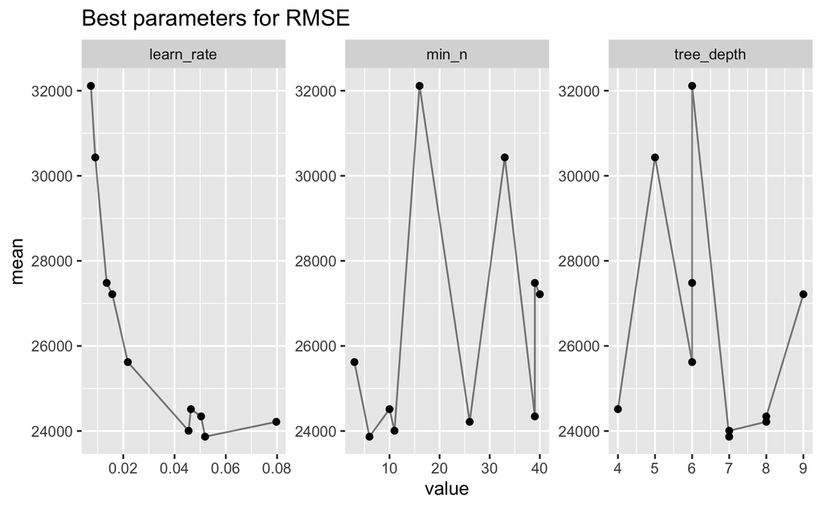

```r
tuned %>%
  show_best(metric = "rmse", n = 10) %>%
  pivot_longer(min_n:learn_rate, names_to = "variable", values_to = "value") %>%
  ggplot(aes(value, mean)) +
  geom_line(alpha = 1/2) +
  geom_point() +
  facet_wrap(~variable, scales = "free") +
  ggtitle("Best parameters for RMSE")
```

Creating the final model with the best parameters:

```r
best_params <-
  tuned %>%
  select_best("rmse")

model_final <-
  model %>%
  finalize_model(best_params)
```

Finding metrics for the training set:

```r
train_processed <- bake(ames_recipe, new_data = ames_train)

trained_model_all_data <- model_final %>%
  fit(formula = sale_price ~ ., data = train_processed)
```

```
Parameter 'cat_features' is meaningless because column types are taken from data.frame.
Please, convert categorical columns to factors manually.
```

```r
train_prediction <- trained_model_all_data %>%
  predict(new_data = train_processed) %>%
  bind_cols(ames_train)

train_prediction %>%
  metrics(sale_price, .pred) %>%
  mutate(.estimate = format(round(.estimate, 2), big.mark = ",")) %>%
  knitr::kable()
```

| .metric | .estimator | .estimate |
| --- | --- | --- |
| rmse | standard | 16,066.88 |
| rsq | standard | 0.96 |
| mae | standard | 11,405.21 |

Without one-hot encoding:

```
|.metric |.estimator |.estimate |
|:-------|:----------|:---------|
|rmse    |standard   |16,066.88 |
|rsq     |standard   |0.96      |
|mae     |standard   |11,405.21 |
```

With one-hot encoding:

```
|.metric |.estimator |.estimate |
|:-------|:----------|:---------|
|rmse    |standard   |19,090.05 |
|rsq     |standard   |0.94      |
|mae     |standard   |13,655.17 |
```

```r
test_processed <- bake(ames_recipe, new_data = ames_test)

test_prediction <- trained_model_all_data %>%
  predict(new_data = test_processed) %>%
  bind_cols(ames_test)

test_prediction %>%
  metrics(sale_price, .pred) %>%
  mutate(.estimate = format(round(.estimate, 2), big.mark = ",")) %>%
  knitr::kable()
```

| .metric | .estimator | .estimate |
| --- | --- | --- |
| rmse | standard | 28,423.69 |
| rsq | standard | 0.87 |
| mae | standard | 16,079.05 |

Without one-hot encoding:

```
|.metric |.estimator |.estimate |
|:-------|:----------|:---------|
|rmse    |standard   |28,423.69 |
|rsq     |standard   |0.87      |
|mae     |standard   |16,079.05 |
```

With one-hot encoding:

```
|.metric |.estimator |.estimate |
|:-------|:----------|:---------|
|rmse    |standard   |29,019.83 |
|rsq     |standard   |0.87      |
|mae     |standard   |17,642.67 |
```

Admittedly not an extraordinary improvement, but CatBoost’s handling of categorical variables improves RMSE by about 2% and MAE by about 10%.

```r
stopCluster(cluster)
```